# business-attributes

## Where most reviews are clustered in US

Among 70k+ businesses registered on Yelp, I wanted to figure out more about what makes a business successful. Before investigating deeper, I decided to look at businesses that has 300+ reviews on Yelp by users in order to get more objective ratings of the business. I filtered the data set to get rid of closed businesses, businesses outside of US and limited the business type to restaurants.

There were only six states that have businesses reviewed more than 300 times.

```r
business <- read_csv("../clean_data/yelp_business.csv")
```

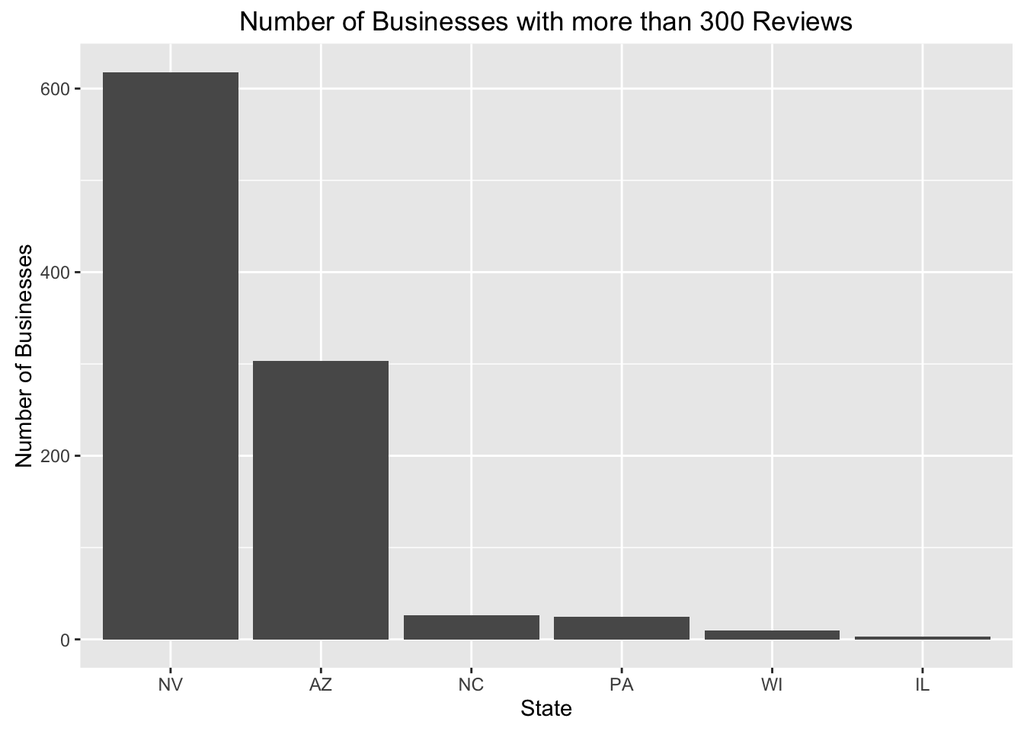

```r
successful_business <- business %>%
  select(-open) %>%
  filter(review_count > 300) %>%
  group_by(state) %>%
  summarise(num = n())

names(business) <- c("id", "open", "categories", "count", "state", "stars", "noise", "attire", "Take-out", "Takes Reservation", "Offers Delivery", "Outdoor Seating", "Accepts Credit Card", "Happy Hour")

ggplot(successful_business, aes(x = reorder(state, -num),
                                y= num)) +
  geom_bar(stat = "identity",
           position = "dodge") +
  labs(title = "Number of Businesses with more than 300 Reviews") +
  xlab("State") +
  ylab("Number of Businesses")
```

## Exploring Attributes

As expected, restaurants with many reviews and/or high ratings were clustered in specific regions.

```r
business_attributes <- business %>%
  filter(count > 300) %>%
  select(-open, -count, -categories, -noise, -attire) %>%
  gather(key=Attribute, value=Val, -id, -state, -stars) %>%
  na.omit
```

There were many attributes per restaurant, and some of them were believed to be influential to a business’ success. I have first chosen six main attributes that seemed critical to the customers’ star ratings.

I gathered all the attributes and used facet_wrap to plot six seperate graphs. The left chunk represents True and the right represents False. There are some states where there’s no applicable values for the specific attribute.

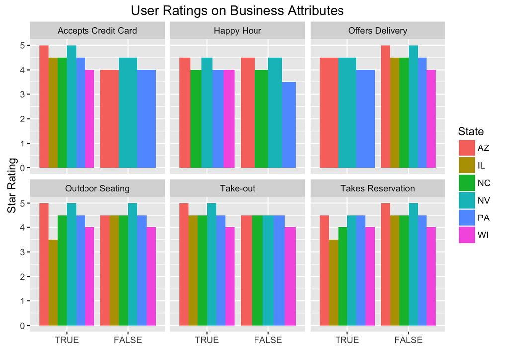

```r
ggplot(business_attributes,
       aes(x = factor(Val,
                      levels = c("TRUE","FALSE")),
           y = stars,
           fill = state)) +
  facet_wrap(~Attribute) +
  geom_bar(stat = "identity",
           position = "dodge") +
  labs(title = "User Ratings on Business Attributes") +
  xlab("") +
  ylab("Star Rating") +
  scale_fill_discrete(name = "State")
```